# [Visão Computacional](https://denmartins.github.io/teaching/2025-visao-computacional)

## Transfer Learning e Arquiteturas de CNN

### [Prof. Dr. Denis Mayr Lima Martins](https://denmartins.github.io/)

### [Pontifícia Universidade Católica de Campinas](https://www.puc-campinas.edu.br/)

## Qual o **maior** problema em depender **apenas** de aprendizado **supervisionado** tradicional?

[figure not shown]

Dados anotados (labeled data) na área da Saúde são caros e difíceis de obter em larga escala. Fonte: [Macgence](https://macgence.com/blog/healthcare-dataset/).

## Treinamento Supervisionado Tradicional

- **Escassez de Dados Rotulados:** Obter dados rotulados é caro e demorado.
- **Generalização Limitada:** Modelos treinados em datasets específicos podem ter dificuldades para generalizar para novos cenários.
- **Necessidade de Engenharia de Features:** Requer conhecimento especializado para selecionar e criar features relevantes.

## O Papel das Features "Universais"

- As **features de baixo nível** (ex: bordas, cantos) são **universalmente úteis** para tarefas de Visão Computacional, independentemente do domínio.
- **Camadas Convolucionais Iniciais:** Estas são o **extrator de características** central de qualquer CNN.
- **Importância da Generalização:** O conhecimento destas camadas (ex: conv1, conv2) tende a se generalizar bem para *datasets* drasticamente diferentes (ex: imagens naturais para imagens médicas).

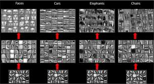

Features extraídas (i.e., aprendidas) por CNNs. Fonte: [Cross Validated](https://stats.stackexchange.com/questions/146413/why-convolutional-neural-networks-belong-to-deep-learning).

## Objetivos de Aprendizagem

- Compreender o conceito de Transfer Learning em Redes Neurais.
- Entender o processo de Pré-Treinamento e como utilizar modelos Pré-Treinados.
- Compreender estratégias de Finetuning.
- Explorar arquiteturas famosas de CNNs.

## Transfer Learning

O Transfer Learning é popular em Deep Learning, pois as Redes Neurais Profundas (DNNs) exigem muitos dados e o custo de treinamento é alto.

**Motivações Principais:**

- **Escassez de Dados:** Resolve a limitação de dados rotulados insuficientes para novos projetos.
- **Custo Computacional:** Reduz o tempo e os recursos (GPU/CPU) necessários para treinar modelos do zero. O treinamento completo é computacionalmente intensivo.
- **Ganhos Empíricos:** Acelera a **convergência** e, em muitos casos, melhora a **acurácia**.

[figure not shown]

Transfer Learning. Fonte: https://toloka.ai/blog/transfer-learning/.

## ImageNet

[figure not shown]

ImageNet dataset.

## Tipos de Transfer Learning

- **Transferência Indutiva:** Tarefas de origem e destino são **diferentes** (ex: pré-treinar para classificação de imagem, adaptar para detecção de objetos).
  - Pode ser Supervisionada (dados rotulados disponíveis).
- **Transferência Transdutiva (Adaptação de Domínio):** As tarefas são as **mesmas**, mas os domínios (distribuição dos dados) são diferentes.
  - Ex: Classificador de carros treinado com fotos de rua (Origem) e adaptado para fotos de satélite (Destino).
- **Transferência Não-Supervisionada:** Tarefas diferentes e não há dados rotulados na tarefa alvo (foco na estrutura dos dados).

## AlexNet

- Possui 8 camadas (5 convolucionais e 3 totalmente conectadas).
- Entrada de imagens $227 \times 227 \times 3$.
- Primeira camada (CONV1) usou $96$ filtros de $11 \times 11$ com *stride* 4.
- O *input* original era dividido em duas GPUs devido à limitação de memória (3 GB na GTX 580).

**Inovações Chave:**

- **ReLU** (Rectified Linear Unit): Foi a primeira utilização de ReLU em larga escala, substituindo *tanh* e *sigmoid*.
- **Max Pooling Sobreposto (Overlap Pooling):** Utiliza filtros $3 \times 3$ com *stride* 2, resultando em regiões de *pooling* que se sobrepõem.
- **Dropout:** Utilizado com probabilidade $0.5$ nas camadas totalmente conectadas (FC) para prevenir **overfitting**.

> Paper: https://proceedings.neurips.cc/paper_files/paper/2012/file/c399862d3b9d6b76c8436e924a68c45b-Paper.pdf

## AlexNet

[figure not shown]

Arquitetura AlexNet. Fonte: [ResearchGate](https://www.researchgate.net/profile/Luis-Santos-23/publication/337400899/figure/fig1/AS:845437196042240@1578579343070/AlexNet-an-example-CNN-architecture-model-14.ppm).

## AlexNet

```
import torch
import torchvision.models as models

# Carrega o modelo pré-treinado
alexnet = models.alexnet(pretrained=True)
```

## VGG

- A VGG16 (16 camadas de peso) e VGG19 (19 camadas de peso) usam exclusivamente camadas convolucionais $3 \times 3$ com *stride* 1 e *padding* 1, e camadas de *max pooling* $2 \times 2$ com *stride* 2.
- Uma pilha de três camadas convolucionais $3 \times 3$ (com *stride* 1) tem o **mesmo campo receptivo efetivo** que uma única camada $7 \times 7$.
- Paper: https://arxiv.org/pdf/1409.1556

**Vantagens do Filtro Pequeno ($3 \times 3$):**

- Permite incorporar **mais não-linearidades** (funções de ativação ReLU).
- Resulta em **menos parâmetros** em comparação com um único filtro grande equivalente, por exemplo, $3 \times (3^2 C^2)$ versus $7^2 C^2$.

**Desvantagens:**

- Possui um **grande número de parâmetros** e é lenta, totalizando 138 milhões de parâmetros na VGG16.

## VGG

[figure not shown]

Arquitetura VGG. Fonte: [ResearchGate](https://www.researchgate.net/publication/368606325/figure/fig3/AS:11431281120912721@1676691089389/The-architecture-of-the-VGG16-model-used-as-ConvNet-encoder.png).

## VGG

```
import torch
import torchvision
import torch.nn as nn
from torchvision import models

model = models.vgg16(pretrained=True)
```

## Vanishing Gradients

## ResNet

- ResNet (Residual Network) resolve o problema de **degradação** que ocorre em redes muito profundas, onde adicionar mais camadas pode levar a um erro de treinamento e teste maior.
- **Degradação vs. Otimização:** Redes profundas (sem atalhos) sofrem de **degradação**, onde o erro de treinamento piora com o aumento da profundidade.

**Conexões Residuais (Skip Connections):**

- A arquitetura ResNet introduz um **bloco residual** que permite que a entrada $x$ seja adicionada à saída das camadas subsequentes: $H(x) = F(x) + x$.
- Isso torna a **propagação do gradiente** muito mais fácil (fluxo de gradiente direto).
- O bloco permite que as camadas aprendam a mapear o **resíduo** $F(x)$, tornando mais fácil para a rede aprender a função identidade se as camadas não forem úteis.
- Paper: https://arxiv.org/pdf/1512.03385 (com mais de 29 mil citações)

[figure not shown]

Skip connection.

## ResNet

[figure not shown]

Arquitetura ResNet. Fonte: [evbn.org](https://www.baeldung.com/wp-content/uploads/sites/4/2022/11/resnet_18_34-e1667587575245.png).

## ResNet

```
import torch
from torch import nn


class ResLayer(nn.Module):
     def __init__(self,ni,no,kernel_size,stride=1):
        super(ResLayer, self).__init__()
        padding = kernel_size - 2
        self.conv = nn.Sequential(
            nn.Conv2d(ni, no, kernel_size, stride,
                      padding=padding),
            nn.ReLU()
        )

    def forward(self, x):
        return self.conv(x) + x
```

> Veja também: https://nn.labml.ai/resnet/index.html

## ResNet

[figure not shown]

Arquitetura ResNet. Fonte: [He, K., Zhang, X., Ren, S., & Sun, J. (2016). Deep residual learning for image recognition. In Proceedings of the IEEE conference on computer vision and pattern recognition (pp. 770-778)](https://www.cv-foundation.org/openaccess/content_cvpr_2016/html/He_Deep_Residual_Learning_CVPR_2016_paper.html).

## U-Net

[figure not shown]

Arquitetura U-Net. Fonte: [Labml](https://nn.labml.ai/unet/index.html).

## Armadilhas Comuns no Transfer Learning

A aplicação incorreta do Transfer Learning pode resultar em consequências negativas, conhecidas como **transferência negativa**.

| Armadilha | Descrição | Dicas de Mitigação |
| --- | --- | --- |
| **Overfitting** em Conjuntos Pequenos | Adaptação excessiva a poucos exemplos no *dataset* alvo. | Usar **taxas de aprendizado muito baixas** (1e-4 a 1e-5), **regularização** (dropout, weight decay), e *data augmentation*. |
| **Esquecimento Catastrófico** | Perda do conhecimento original (da tarefa fonte) durante o fine-tuning para a tarefa alvo. | Aplicar **congelamento seletivo** nas camadas iniciais ou usar técnicas avançadas como regularização elástica. |
| **Deslocamento de Domínio** (Transferência Negativa) | O conhecimento transferido prejudica o desempenho porque os domínios de origem e destino são muito dissimilares. | Garantir que a **distribuição** dos dados de origem e destino sejam semelhantes e que as tarefas sejam relacionadas. |

## Fine-Tuning

O Fine-tuning é o processo de retreinar um modelo pré-treinado usando uma taxa de aprendizado menor para se adaptar a uma tarefa específica.

**Técnicas de Ajuste de Pesos:**

- **Congelar Camadas (Feature Extraction Puro):** As camadas inferiores (extrator de características) são mantidas intactas (*frozen*), preservando as **features universais** (bordas, texturas). Apenas a camada final de classificação é treinada do zero.
- **Taxas de Aprendizado Diferenciadas (Layer-wise Learning Rate Decay):** Aplica-se taxas de aprendizado progressivamente menores para camadas mais próximas da entrada. Isso evita a destruição de conhecimento fundamental.
- **Treinamento em Poucas Épocas:** Geralmente, 2–10 épocas são suficientes para a nova tarefa, monitorando com *early stopping*.

## Estratégias de Uso de Modelos Pré-Treinados

[figure not shown]

Abordagens de uso. Fonte: [Raschka](https://magazine.sebastianraschka.com/p/using-and-finetuning-pretrained-transformers).

## Fine-tuning: Exemplo

```
model = models.vgg16(pretrained=True)

# Congela os pesos da rede original
for param in model.parameters():
    param.requires_grad = False

model.classifier = nn.Sequential(
    nn.Flatten(),
    nn.Linear(512, 128),
    nn.ReLU(),
    nn.Dropout(0.2),
    nn.Linear(128, 1),
    nn.Sigmoid()
)
```

## Conclusão e Próximos Passos

- **Necessidade Crucial:** Transfer Learning é indispensável para superar a **escassez de dados** e o **alto custo computacional** em deep learning.
- **Transferência Hierárquica:** CNNs aprendem **features hierárquicas**; as camadas iniciais (bordas, blobs) são universais e devem ser preservadas (congeladas).
- **Fine-tuning é Delicado:** O ajuste fino requer o uso de **baixas taxas de aprendizado** para evitar a sobreescrita do conhecimento valioso pré-adquirido.
- **ResNet é o Default Atual:** Arquiteturas como **ResNet** (152 camadas, conexões residuais) se tornaram o padrão, superando problemas de otimização em redes extremamente profundas.
- Outras arquiteturas famosas: Inception, DenseNet, U-Net, EfficientNet, MobileNet.
- Exemplos de código em https://github.com/rasbt/deeplearning-models
- Repositório de Modelos: https://github.com/huggingface/pytorch-image-models